# Soccer players' age analysis

This brief anaysis initially came from a conversation with friends. Looking at the young generation taking place in national teams (especially in France), we were wondering if we were still young enough to be soccer players while we all reached 30.  
This notebook is then dedicated to answer these simple questions :

> - What is the average age of a soccer player ? To answer this question, we'll look at the distribution of player's age, and its evolution.
> - What is the best age for a soccer player ? That is to say, when does a player reach its maximum performance ? And why : what are the attributes that decline with the age (and what are those which improve, like experience) ?

To answer these questions, I rely on the *European Soccer Database* which contains a lot of information on player (age, skills, rating...) from the videogame FIFA. The data is then obviously subjective (everyone has a different opinion on player's performances) and is focused on European championship, but this would be sufficient for this analysis.

Before getting down to the stats, I'd like to precise that I welcome constructive criticism and would love to hear your thoughts about this topic. But remember that this is a concise case study, made to clarify a discussion "over the counter", and clearly not a **deep** data analysis.

*Table of contents*

1. Load, clean and transform data
2. Average age of soccer player
3. The best age to be a soccer player
4. Conclusion

## Load, clean and transform data

```python
# Import Libraries
import sqlite3
import pandas as pd
import numpy as np
import matplotlib.pyplot as plt
import seaborn as sns
from sklearn.ensemble import RandomForestClassifier
from sklearn.model_selection import train_test_split
from sklearn.feature_selection import SelectFromModel
from sklearn.metrics import accuracy_score

# I use the xkcd theme for charts design, perfect for an informal analysis like this one
# (go check the xkcd website for those who don't know this gem)
plt.xkcd()
sns.set()
sns.set_style('whitegrid') # I always prefer to have a grid to help read charts

%matplotlib inline
```

```python
# Get the 2 tables on players in the database
cnx = sqlite3.connect('../input/database.sqlite')
df_attributes = pd.read_sql_query("SELECT * FROM Player_Attributes", cnx)
df_names = pd.read_sql_query("SELECT * FROM Player", cnx)
```

```python
# Merge datasets in a single table
df = (pd.merge(df_attributes, df_names, how = "left", on="player_api_id")
      .dropna())

# Remove non relevant columns
df = df.drop(['id_x','id_y','player_fifa_api_id_x','player_fifa_api_id_y'],axis = 1)

# Convert Dates columns to date format in pandas
df["birthday"] = pd.to_datetime(df["birthday"])
df["date"] = pd.to_datetime(df["date"])
df["date_year"] = df["date"].apply(lambda x : x.year)

# Calculate approximate age in years
df["age"] = (df["date"].apply(lambda x : x.year) - df["birthday"].apply(lambda x : x.year)
            .astype(float))
```

## Average age of soccer player

The purpose of this section is to briefly look at the average age for a soccer player. We will then see if it varies over time.

```python
# Number of records per year
df[["date_year", "date"]].groupby("date_year").count()
```

| date_year | date |
| --- | --- |
| 2007 | 14331 |
| 2008 | 5248 |
| 2009 | 8360 |
| 2010 | 10392 |
| 2011 | 11860 |
| 2012 | 12625 |
| 2013 | 38830 |
| 2014 | 32792 |
| 2015 | 31818 |
| 2016 | 14098 |

Then why a **single year** ?  
I chose to only rely on a single calendar year to avoid counting the same player age several times, even if this would not be ultimately problematic. This will moreover allow to study the evolution in time in a second part.

```python
# Calculate the number of players per age on 2015
df_age_2015 = (df[df["date_year"] == 2015] # Filter to keep only 2015 data
              .groupby("player_api_id")
              .agg({"age" : "max"}) # if a player has more than 2 records for 2015, keep only the latest
              .reset_index()
              .groupby("age")
              .count()
              .rename(columns ={"player_api_id" : "number of players"}))

# Calculate proportion and cumulative proportion per age
df_age_2015["players prop"] = df_age_2015["number of players"] / df_age_2015["number of players"].sum()
df_age_2015["players cum prop"] = df_age_2015["players prop"].cumsum()
```

```
the mean age for 2015 is 26.66 years
```

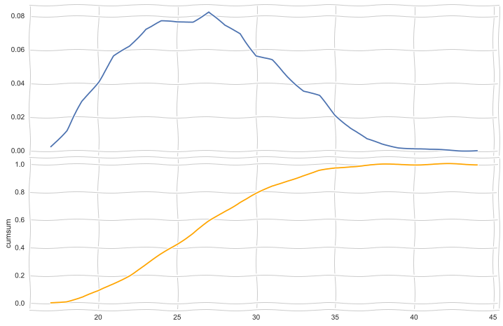

```python
# Plot the 2 distributions
fig = plt.figure()
ax1 = fig.add_subplot(2,1,1)
ax2 = fig.add_subplot(2,1,2)
fig.set_size_inches(12, 8)

ax1.plot(df_age_2015[["players prop"]])

ax2.plot(df_age_2015[["players cum prop"]], color = "orange")
ax2.set_ylabel("cumsum")

plt.subplots_adjust(hspace=0)

mean_age = interq_range =(df[df["date_year"] == 2015]
               .groupby("player_api_id")
               .agg({"age" : "max"})
               .rename(columns = {"age" : "mean"})
               .mean())["mean"]
print("the mean age for 2015 is {0:.2f} years".format(mean_age))
```

Looks like 30 years old is not that old : even if the average age is 26.7, a look at the cumulative distribution chart tells us that 30 years old is close to be the **3rd quartile (0.75)** of this distribution, meaning that 25% of players are 30 or older !

For the following part, I will prefer to use the median (and other quartiles) as a way to represent the average : the mean is known to be too sensible to outliers.

Let's take then a closer look at the interquartile range (I added min and max for reference) :

```python
# Calculate quantile, min and max
interq_range =(df[df["date_year"] == 2015]
               .groupby("player_api_id")
               .agg({"age" : "max"})
               .rename(columns = {"age" : "age quantile"})
               .quantile([0,0.25,0.5, 0.75, 1]))
interq_range
```

|  | age quantile |
| --- | --- |
| 0.00 | 17.0 |
| 0.25 | 23.0 |
| 0.50 | 26.0 |
| 0.75 | 30.0 |
| 1.00 | 44.0 |

This confirms what we've just seen : 30 years old is *exactly* the 3rd quartile. This means there's still hope !

I was first suspicious as it looks like 30 years old is closer to 80% percentile on the chart, but if we take a look at our cumulative proportion, we see that 30 years old IS indeed the 75% percentile. Some might argue that this a matter of methodology... which is a bit true ! But I prefer to be optimistic on this one.

```python
# Take a look at players proportion for 29 and 30 years old
df_age_2015.loc[[29,30]]
```

| age | number of players | players prop | players cum prop |
| --- | --- | --- | --- |
| 29 | 521 | 0.069448 | 0.729672 |
| 30 | 422 | 0.056252 | 0.785924 |

Now it will be interesting to see how players age has evolved over time : is the average age of players getting younger (as it looks like as I am getting older) ?

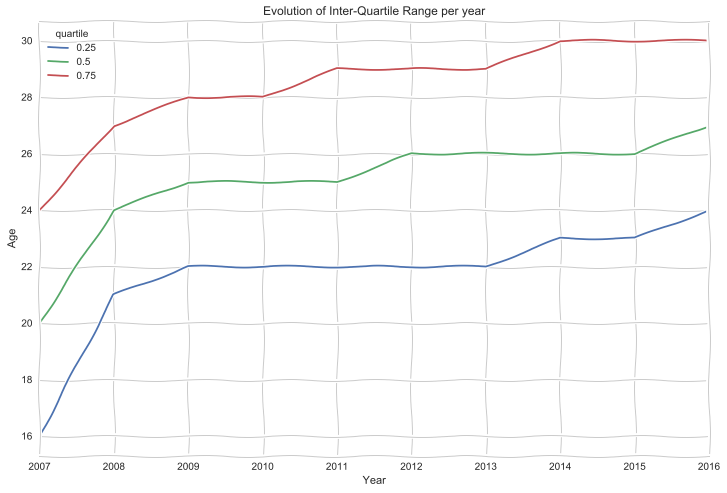

```python
# Calculate the interquartile range over years
iqr_evolution = (df.groupby(["date_year", "player_api_id"])
    .agg({"age":"max"})
    .reset_index()
    .groupby("date_year")
    .quantile([0.25,0.5, 0.75])
    .drop("player_api_id", axis = 1)
    .reset_index()
    .rename(columns = {"level_1" : "quartile"})
    .pivot_table("age", index = "date_year", columns = "quartile"))

# Plot the evolution on a line chart
plot_iqr_year = iqr_evolution.plot(figsize=(12,8))
plot_iqr_year.set_title("Evolution of Inter-Quartile Range per year")
plot_iqr_year.set_xlabel("Year")
plot_iqr_year.set_ylabel("Age")
```

Good news ! It looks like the average age of players is surprisingly increasing. However, we should temper this encouraging finding : as we saw previously, there are some years that does not seem to be complete in this database, and it probably impacts this chart. The year 2007 looks especially supicious.

## The best age to be a soccer player

Now that we saw that there is still hope for people in their thirties, let's see what is the best age for a player, that is to say, when does he have the best performance on the field ? We will try then to understand why : maybe some attributes decline over time (speed ?) but some characteristics should conversely increase with years, as the player get experience. Let's find out !

In the database numerous **features** are recorded on a numeric scale : for example heading_accuracy, shot_power, ect. We are going to consider only those features for our analysis. Some other attributes are ordinal (e.g. attacking_work_rate which can be "low / medium / high") or even categorical (preferred_foot). We will not take them into account as they are either too vague (for ordinal values) or non relevant : as mentionned, we will **select numeric features only**.

```python
# Remove non numeric features like preferred_foot. We can use this quick and dirty method as age and our ID
# column (player_api_id) are also numeric.
df = df.select_dtypes([np.number])
```

Now that we have selected our features (or columns), it is time to think about **filtering** : the database contains a lot of records, but only some of them are relevant for our analysis. For example, we do not want to consider players that have too few records. We will not be able to analyse a trend based on rare samples of their performance.

```python
# Filter data : keep only players with stats from 20 to 30 years old and with more than 10 data points
players_to_keep = (df.groupby("player_api_id")
                  .agg({"age" : ["min", "max", "count"]}))
players_to_keep = players_to_keep[(players_to_keep["age","count"] <= 20) &
                   (players_to_keep["age", "max"] >= 30) &
                   (players_to_keep["age", "count"] >= 10)].index
df = df[(df["player_api_id"].isin(players_to_keep)) &
       (df["age"] > 19) & (df["age"] < 35)]
```

Finally we want to **norm** the attributes we want to analyze. Each player have different characteristics, but we want to understand how they evolve over time, not between players.

To align players on the same scale, we are going to norm based on the max of their value. This will help us understand at what age players generally reach their peak performance.

```python
# Norm the data : as we are interested to know when a player is better,
# we will norm based on the max value of each feature.
not_to_norm = ["age", "player_api_id", "date_year"] # not every column is relevant to norm !
for dim in df:
    if dim not in not_to_norm :
        df["normed_" + dim] = df.groupby("player_api_id")[dim].apply(lambda x : x / x.max())
```

Now that our data is ready to process, let's quickly draw the average evolution of player rating !

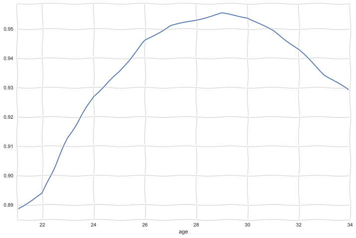

```python
rating_age = df.groupby("age")["normed_overall_rating"].mean()
rating_age.plot(figsize=(12,8))
```

Interesting ! On average soccer players seem to reach their **peak performance at the age of 29**. Like wines, players need to age a bit to be better !  
But how can we explain this trend ? Is experience offsetting the lowering of physical performance ? We will take a look at the other attributes to better understand this phenomenon.

First, like we did for the overall rating, let's draw the evolution of the features over time.

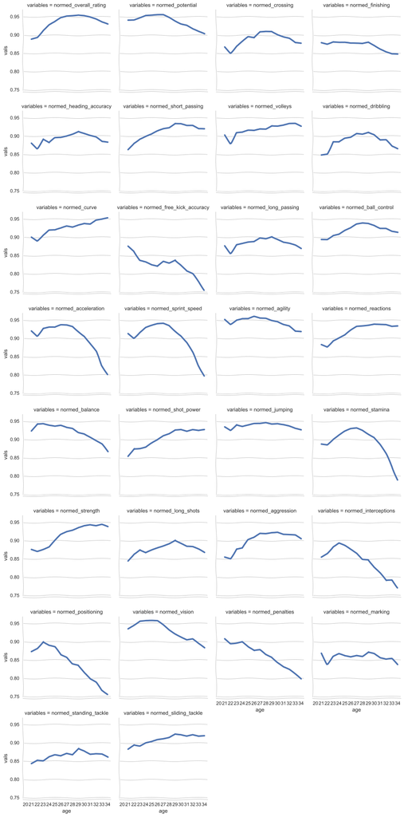

```python
# Create a dataframe that group attribute per age
kpi_age = df.groupby("age").mean()[['normed_overall_rating', 'normed_potential',
       'normed_crossing', 'normed_finishing', 'normed_heading_accuracy',
       'normed_short_passing', 'normed_volleys', 'normed_dribbling',
       'normed_curve', 'normed_free_kick_accuracy', 'normed_long_passing',
       'normed_ball_control', 'normed_acceleration', 'normed_sprint_speed',
       'normed_agility', 'normed_reactions', 'normed_balance',
       'normed_shot_power', 'normed_jumping', 'normed_stamina',
       'normed_strength', 'normed_long_shots', 'normed_aggression',
       'normed_interceptions', 'normed_positioning', 'normed_vision',
       'normed_penalties', 'normed_marking', 'normed_standing_tackle',
       'normed_sliding_tackle']].reset_index()

# Melt the attributes (in columns) in a single column : this will ease the creation of the plots
kpi_age_melt = kpi_age.melt("age", var_name='variables', value_name='vals')

# Plot the evolution of each feature over time
g = sns.FacetGrid(kpi_age_melt, col="variables", col_wrap=4)
g = g.map(sns.pointplot, "age", "vals", ci=None, markers = "", order = range(20,35))
```

As expected, the trends are diverse depending on the features : some attributes increase over time (like the strength) and others drop (surprisingly the penalties : do players get more predictable ?). Finally, some characteristics like the jumping skills seem to remain constant.

To facilitate the reading, which is a bit messy with all these charts, let's summarize the correlation coefficient of each feature with the age in a bar plot. This will allow to quickly see which feature positively correlate with age, and then get better over time.  
Let's just note that these coefficients are calculated based on a **linear regression** and thus may not fully embrace the subtleties of their interaction. For example look above at the chart of the stamina : its evolution over age is clearly more complex than a linear regression (maybe a polynomial one ?). But these coefficient will enable us to understand the general trend between feature and age.

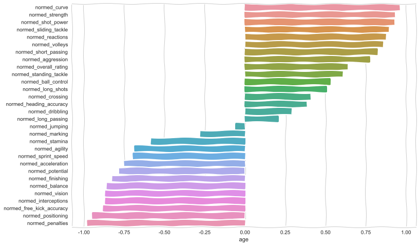

```python
corr_kpi = kpi_age.corr()
corr_kpi = (corr_kpi[["age"]]
           .sort_values("age", ascending = False)
           .drop("age", axis = 0))

fig, ax = plt.subplots()
fig.set_size_inches(12, 8)

sns.barplot(x = "age", y = corr_kpi.index, data = corr_kpi)
```

This chart is a good way to understand which attributes get better with age (curve, strength...) and which ones get worse (penalties, positioning...).

We're almost there, but I feel something is missing : why are players regarded as better when they are almost at their thirties (at least considering the ratings of this dataset). Is it because strength is more important than penalties ? Is it because only shot power really matters and, as it increases with age, player ratings get better ?  
We need to better understand the **importance** (or significance) of each attribute on the ratings. That's a topic where domain expertise is especially useful, but as I am not really into soccer (I clearly prefer rugby), I will use some machine learning tools to help me detect the most important features.

There are several methods to perform a **feature selection** from a dataset. Given that the features are probably not linearly correlated to rating (remember the previous line charts ?), I will use the Random Forest algorithm and not any linear model (like linear regression) for this task.

```python
features_to_consider = ['normed_crossing', 'normed_finishing', 'normed_heading_accuracy',
       'normed_short_passing', 'normed_volleys', 'normed_dribbling',
       'normed_curve', 'normed_free_kick_accuracy', 'normed_long_passing',
       'normed_ball_control', 'normed_acceleration', 'normed_sprint_speed',
       'normed_agility', 'normed_reactions', 'normed_balance',
       'normed_shot_power', 'normed_jumping', 'normed_stamina',
       'normed_strength', 'normed_long_shots', 'normed_aggression',
       'normed_interceptions', 'normed_positioning', 'normed_vision',
       'normed_penalties', 'normed_marking', 'normed_standing_tackle',
       'normed_sliding_tackle'] # Note that we removed normed_potential as it is rather a rating than a feature

X = df[features_to_consider]
y = df["normed_overall_rating"].apply(lambda x: int(x))

# Create a random forest classifier
clf = RandomForestClassifier(n_estimators=10000, random_state=0, n_jobs=-1)

# Train the classifier
clf.fit(X, y)
```

```
RandomForestClassifier(bootstrap=True, class_weight=None, criterion='gini',
            max_depth=None, max_features='auto', max_leaf_nodes=None,
            min_impurity_decrease=0.0, min_impurity_split=None,
            min_samples_leaf=1, min_samples_split=2,
            min_weight_fraction_leaf=0.0, n_estimators=10000, n_jobs=-1,
            oob_score=False, random_state=0, verbose=0, warm_start=False)
```

Note that we did not split our dataset between a training set and a test set as it is generally done : our objective here is not to predict, but to **explain** our dataset.

Let's see what we've got by plotting the importance of each feature.

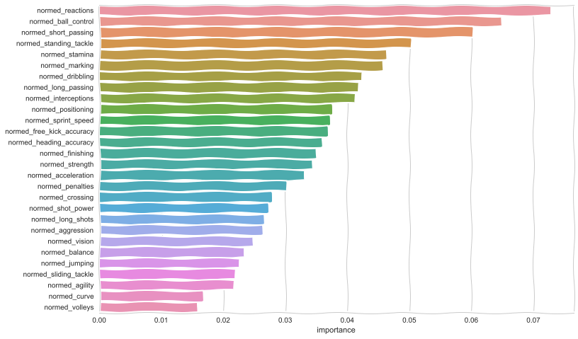

```python
# Store the name and importance of each feature in a dataframe
df_feature_importance = (pd.DataFrame(clf.feature_importances_,
                                     index = features_to_consider,
                                     columns = ["importance"])
                        .sort_values(by = "importance", ascending = False))

fig, ax = plt.subplots()
fig.set_size_inches(12, 8)

sns.barplot(x = "importance", y = df_feature_importance.index, data = df_feature_importance)
```

To be honest, I was expecting a much higher discrepancy between the features importance, but all of them ranges from about 2% to 7%. Reactions, ball control and short passing are clearly decisive to have a good rating, but these 3 account for about 20% of the total feature importance (which sum to 1). The other features cannot then be omitted.

Let's get back to the correlation coefficient between age and features that we calculated earlier, and compare them with the importance of each feature on the player rating. This will give us a sense of which feature actively contribute to the rise of the rating over age and conversely.

It will be interesting to plot it as the bar chart : the correlation coefficient will represent the value of the bar, while the importance of this feature will be represented as the "weight" of the bar.

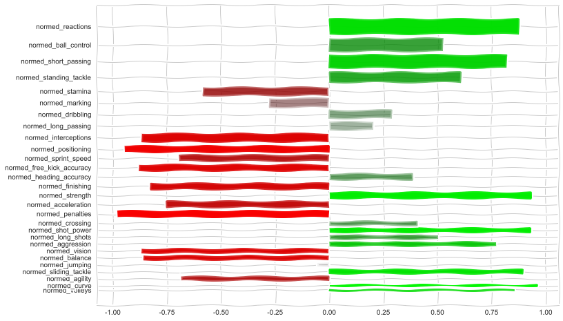

```python
# Perform an inner join between our correlation coefficient dataframe and the one with feature importance
# Note that we perform an inner join to get rid of "normed_potential" in the correlation coef df which is not
# relevant in this context
df_trend_importance = (pd.merge(corr_kpi,
                               df_feature_importance,
                               left_index = True,
                               right_index = True,
                               how = "inner")
                      .sort_values(by = "importance", ascending = True))

fig, ax = plt.subplots()
fig.set_size_inches(12, 8)

# Calculate the rounded importance of each feature. this will be used to determined the height of
# the bar chart
h = df_trend_importance["importance"].apply(lambda x : int (x *100)).tolist()

# Calculate y position on the chart
y_pos = [0]
for i in range(1, len(h)):
    y_pos.append(y_pos[i - 1] + h[i] + 1)

# Calculate the RGBA colors for each feature :
# negative correlation with age will be red and positive correlation will be green
col = []
for j in range(len(df_trend_importance["age"])):
    if df_trend_importance["age"][j] > 0:
        col.append((0,df_trend_importance["age"][j],0,df_trend_importance["age"][j]))
    else :
        col.append((abs(df_trend_importance["age"][j]),0,0,abs(df_trend_importance["age"][j])))

# Plot the chart
g = plt.barh(y_pos,
             height = h,
             width = df_trend_importance["age"],
            color = col)
g = plt.yticks(y_pos, df_trend_importance.index)
```

The 3 most important features for a player (reaction, ball control and short passing) increase over time, hence the fact that the rating is mainly rising (up until 29). Stamina, interceptions, positionning and other features related to speed are on the other hand decreasing, but their importance is lower.

## Conclusion

Let's wrap this up :

- We saw that even if the average age of a soccer player is about 27 years (at least in 2015), 25% of the players are 30 or older
- We observed that players reach their peak performance at about 29 before dropping
- Soccer players performance increase until that age because they get better at reactions, ball control and passing. On the other hand their stamina and other speed related features contribute to slightly decrease their performance

Despite these encouraging results, I doubt to be a professional soccer player tomorrow. First because I still have not done any training, but also because this analysis does not cover the transfer from an amateur practice to a professionnal environment. This was a quick and dirty study to get an overview on the effect of age on *professionnal* soccer players, and even in this domain, a lot has still to be considered : are these results relevant for each field position (goalkeeper, defender...) ? Are there discrepancies between countries ? Ect.

I'd love to hear your thoughts on this !